# Доклад по математическому моделированию

Совместное принятие решений

Сидорова Н.А.

Российский университет дружбы народов, Москва, Россия

Объединённый институт ядерных исследований, Дубна, Россия

30 марта 2025

# Информация

## Докладчик

- Сидорова Наталья Андреевна
- НфИбд-01-22
- Российский университет дружбы народов
- 1132226432@pfur.ru
- https://nasidorova.github.io/ru/

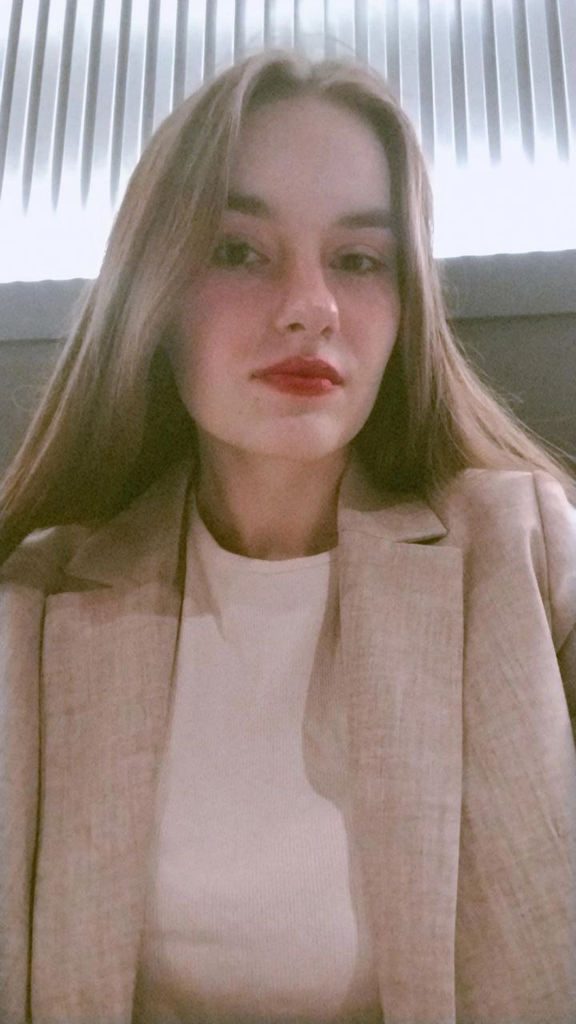

# Вводная часть

## Актуальность темы

В современных условиях принятие решений часто становится коллективной задачей из-за неопределенности и множества заинтересованных сторон. Это актуально для управления, экономики, здравоохранения и других сфер. Рост информационной нагрузки и разнообразие мнений подчеркивают важность эффективных методов коллективного решения.

## Объект и предмет исследования

Объект исследования: процессы коллективного принятия решений в сложных системах. Предмет исследования: методы математического моделирования, используемые для анализа и оптимизации коллективных решений, а также алгоритмы, способствующие нахождению консенсуса.

## Гипотеза

Применение интегрированного подхода, объединяющего методы многокритериального анализа и теорию игр, позволит добиться более эффективного и устойчивого консенсуса в ситуациях, характеризующихся сложной динамикой и неопределенностью.

## Материалы исследования

1. Литературный обзор по методам принятия решений, теории игр и многокритериальному анализу.
2. Данные, полученные из кейс-исследований в области управления проектами и корпоративного управления.

## Методы и инструменты

1. Математическое моделирование
2. Теория игр
3. Методы оптимизации и многокритериального анализа
4. Численные методы
5. Статистический анализ для оценки параметров и поведения модели.

# Основная часть

## Содержание исследования

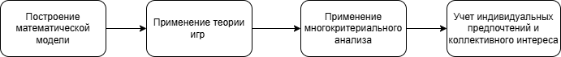

Содержание исследования

## Основные этапы работы

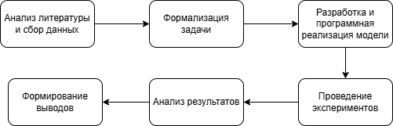

Этапы работы

## Вывод

1. Интеграция методов теории игр и многокритериального анализа позволяет более точно описывать и оптимизировать процессы коллективного принятия решений.
2. Разработанная математическая модель является надежным инструментом для анализа и поддержки решения в условиях неопределенности и сложных взаимосвязей.
3. Практическая реализация модели подтверждает её эффективность и перспективность для использования в реальных управленческих и проектных процессах.
4. Дальнейшие исследования могут быть направлены на улучшение алгоритмов коммуникации между участниками и адаптацию модели под специфические отраслевые задачи.